# Machine Learning - Final Project. Predicting the quality of dumbbell excercises

Jaime Leal

27 January 2019

## Download the data sets

The data for this project comes from this source: http://groupware.les.inf.puc-rio.br/har

```r
training_url <- "https://d396qusza40orc.cloudfront.net/predmachlearn/pml-training.csv"
testing_url <- "https://d396qusza40orc.cloudfront.net/predmachlearn/pml-testing.csv"

training <- read.csv(url(training_url))
testing <- read.csv(url(testing_url))

print(dim(training))
```

```
## [1] 19622   160
```

## Data cleaning

```r
# Fix typo in column names. From "picth" to "pitch"
colnames(training) <- gsub("picth","pitch",colnames(training))
colnames(testing) <- gsub("picth","pitch",colnames(testing))
```

## Feature selection

**Excluded features**

From the analysis we exclude the calculated features and concentrate in the raw sensor data. We get the list of calculated features from the [paper](http://groupware.les.inf.puc-rio.br/work.jsf?p1=11201). Also, we exclude the columns related to the time of the measurement and `X` because it is just the row number. This reduces the number of features from 159 to 41.

```r
calculated_features_1 = grep("roll|pitch|yaw",colnames(training), value = T)
calculated_features_2 = grep("min|max|avg|var|stddev|kurtosis|amplitude", colnames(training), value = T)
calculated_features = union(calculated_features_1, calculated_features_2)

id_cols = c("X"
            ,"raw_timestamp_part_1"
            ,"raw_timestamp_part_2"
            ,"cvtd_timestamp"
            ,"new_window"
            ,"num_window"  )


cols_to_exclude = c(calculated_features, id_cols)
# Print the list of selected features
print(setdiff(colnames(training),cols_to_exclude))
```

```
##  [1] "user_name"            "total_accel_belt"     "gyros_belt_x"
##  [4] "gyros_belt_y"         "gyros_belt_z"         "accel_belt_x"
##  [7] "accel_belt_y"         "accel_belt_z"         "magnet_belt_x"
## [10] "magnet_belt_y"        "magnet_belt_z"        "total_accel_arm"
## [13] "gyros_arm_x"          "gyros_arm_y"          "gyros_arm_z"
## [16] "accel_arm_x"          "accel_arm_y"          "accel_arm_z"
## [19] "magnet_arm_x"         "magnet_arm_y"         "magnet_arm_z"
## [22] "total_accel_dumbbell" "gyros_dumbbell_x"     "gyros_dumbbell_y"
## [25] "gyros_dumbbell_z"     "accel_dumbbell_x"     "accel_dumbbell_y"
## [28] "accel_dumbbell_z"     "magnet_dumbbell_x"    "magnet_dumbbell_y"
## [31] "magnet_dumbbell_z"    "total_accel_forearm"  "gyros_forearm_x"
## [34] "gyros_forearm_y"      "gyros_forearm_z"      "accel_forearm_x"
## [37] "accel_forearm_y"      "accel_forearm_z"      "magnet_forearm_x"
## [40] "magnet_forearm_y"     "magnet_forearm_z"     "classe"
```

**Selected features**

For each of the 4 sensors:

1. Belt
2. Arm
3. forearm
4. Dumbbell

there are 10 raw measurements:

1. Total acceleration
2. Gyros_x
3. Gyros_y
4. Gyros_z
5. Acceleration_x
6. Acceleration_y
7. Acceleration_z
8. Magnet_x
9. Magnet_y 10.Magnet_z

Giving a total of 40 features, plus the `username`,that will be used to predict `classe`.

### Zero variance

We check for zero variance, to see if there is an opportunity to drop some columns. But none of the columns have zero variance.

```r
zero_var <- nearZeroVar(training %>% select(-one_of(cols_to_exclude)),names = T)
print(zero_var)
```

```
## character(0)
```

### Missing values

The features that we selected are complete and there is no reason to impute.

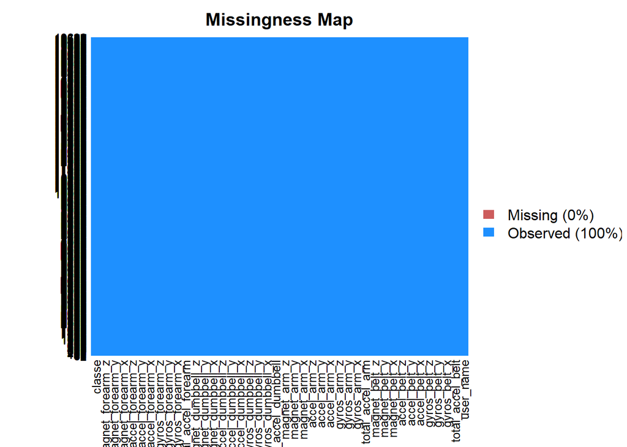

```r
Amelia::missmap(training %>% select(-one_of(cols_to_exclude)))
```

## Model training and selection

We train 5 models in the training data set: rf, gbm, knn, lda, qda; and then we choose the best one based on its accuracy.

**Cross validation**: We perform 10 k-fold Cross Validation to choose the best parameters for the model and to estimate the out of bag (OOB) error. We specify this condition in the `trainControl` object.

```r
# Formula
cols = setdiff(colnames(training), cols_to_exclude)
cols = setdiff(cols, "classe")
formula_str = sprintf("classe ~ %s", paste(cols,collapse = "+"))


cluster <- makeCluster(detectCores() - 1)
registerDoParallel(cluster)

fitControl <- trainControl(method = "cv",
                           number = 10)
set.seed(1234)
mod_rf <- train(as.formula(formula_str), training, method = "rf", trControl = fitControl)
mod_gbm <- train(as.formula(formula_str), training, method = "gbm", trControl = fitControl)
mod_knn <- train(as.formula(formula_str), training, method = "knn", trControl = fitControl)
mod_lda <- train(as.formula(formula_str), training, method = "lda", trControl = fitControl)
mod_qda <- train(as.formula(formula_str), training, method = "qda", trControl = fitControl)

stopCluster(cluster)
registerDoSEQ()
```

## Selected model: random forest

We choose the random forest model because it has the highest accuracy of the 5 models.

```r
results = data.frame(
models = c("rf","gbm","knn","lda","qda"),
Accuracy = c( max(mod_rf$results$Accuracy)
             ,max(mod_gbm$results$Accuracy)
             ,max(mod_knn$results$Accuracy)
             ,max(mod_lda$results$Accuracy)
             ,max(mod_qda$results$Accuracy))
)

results <- results %>% arrange(-Accuracy)
print(results)
```

```
##   models  Accuracy
## 1     rf 0.9892982
## 2    knn 0.9111714
## 3    gbm 0.9085705
## 4    qda 0.8400288
## 5    lda 0.6808686
```

## Confusion matrix and out of bag (OBB) error

The OBB error is estimated at 0.9%.

```r
print(mod_rf$finalModel$confusion)
```

```
##      A    B    C    D    E class.error
## A 5573    2    1    3    1 0.001254480
## B   35 3742   20    0    0 0.014485120
## C    0   23 3398    1    0 0.007013442
## D    4    0   77 3133    2 0.025808458
## E    0    1    0    6 3600 0.001940671
```

```r
#https://jarrettmeyer.com/2016/10/20/quickly-computing-oob-error-estimates

computeOOBErrEst <- function (x)
{
  cm <- x$confusion
  cm <- cm[, -ncol(cm)]
  1 - sum(diag(cm)) / sum(cm)
}

print(sprintf("OBB error is: %s %%",round(computeOOBErrEst(mod_rf$finalModel)*100,2)))
```

```
## [1] "OBB error is: 0.9 %"
```

## Predict test set for submission

```r
prediction <- predict(mod_rf,testing)
print(data.frame(problem_id = testing$problem_id, classe = prediction))
```

```
##    problem_id classe
## 1           1      B
## 2           2      A
## 3           3      B
## 4           4      A
## 5           5      A
## 6           6      E
## 7           7      D
## 8           8      B
## 9           9      A
## 10         10      A
## 11         11      B
## 12         12      C
## 13         13      B
## 14         14      A
## 15         15      E
## 16         16      E
## 17         17      A
## 18         18      B
## 19         19      B
## 20         20      B
```